# Likelihood Inference for Jump Diffusions

Etienne A.D. Pienaar

February, 2016

# Constructing the likelihood

Before reading this section, it might be worth while – for statisticians unfamiliar with likelihood inference in the context of diffusion processes – to read the section on likelihood inference for purely diffuse processes in the [**DiffusionRgqd**](https://cran.r-project.org/package=DiffusionRgqd) package. However, the concepts outlined here follow naturally from those outlined in the vignette on generating transition densities.

Consider a process observed discretely at time epochs $t_1,t_2,\ldots, t_n$ giving rise to the time series $D_S = \{\mathbf{X}_{t_1},\mathbf{X}_{t_2},\ldots,\mathbf{X}_{t_n}\}$. In the case of jump free diffusions we operate under the assumptions that the time series is observed without error (or at least a high degree of precision) and that the data generating process is a jump free process. Discarding the latter assumption and allowing for the data generating process to contain jumps presents subtle yet significant complications with respect to performing inference in practice. Whilst accounting for discontinuous behaviour in a diffusion model by including a jump processes in the dynamics of a model may serve to explain important features of the data at hand, it is important to note that it creates an element of inherent latency when the process of interest is observed at discrete points within a finite time horizon. This follows since we only observe the diffuse part of the underlying process in the sense that the jump part is only visible through its effect on the trajectories of the diffuse part, $X_t$. This latency manifests in various ways depending on the nature of the jump process and the resolution of the observed series. Collectively these difficulties amount to informational latency rather than a methodological issue. For example, in practice, it would rarely be a problem to have an immeasurably weak jump signal as the motivation for modelling real world phenomena with a jump diffusion model usually stems from *a priori* knowledge of the presence of ‘jump’ behaviour in an observed series (Honore 1998). This however does not preclude the quality of such a signal. Furthermore, having strong evidence for the presence of jump does not circumvent the need for a sufficiently long time series. This stems from the fact that we have to distil both the rate at which jumps occur (long run dynamics) as well as the distributional qualities of the jumps (instantaneous dynamics) from the distorted signal - whatever the data resolution may be.

Given observations $D_S$ and some jump diffusion model parametrized by the vector $\boldsymbol\theta$, we can formulate the likelihood mathematically from the transitional density using the usual Markov arguments:
$$L(\boldsymbol\theta|D_S) \propto \prod_{i=1}^{n-1} f(\textbf{X}_{t_{i+1}}|\textbf{X}_{t_{i}},\boldsymbol\theta).$$
Subsequently applying the excess factorization (see the vignette on generating transition densities for more details on the factorization), we can write the likelihood as:
$$\begin{aligned}
L(\boldsymbol\theta|D_S) \propto& \prod_{i=1}^{n-1}\bigg( P(\textbf{N}_{t_{i+1}}-\textbf{N}_{t_{i}}=0)f_D(\textbf{X}_{t_{i+1}}|\textbf{X}_{t_{i}},\boldsymbol\theta)+P(\textbf{N}_{t_{i+1}}-\textbf{N}_{t_{i}}>0)f_E(\textbf{X}_{t_{i+1}}|\textbf{X}_{t_{i}},\boldsymbol\theta)\bigg).\\
\end{aligned}$$
Using this formulation, the ability to perform inference on jump diffusions hinges on the data being of sufficiently high resolution and/or the jump signal being strong enough at the given resolution, in order for the information about the jump process to manifest as the contrast between the diffuse and the excess distributions $f_D(.)$ and $f_E(.)$ respectively. Fortunately, as is the nature of datasets to which jump models are applied, that presence of a jump signal is usually what motivates the use of a jump diffusion model in the first place. Thus, using the moment truncation methodology in conjunction with the excess factorization, it is possible to perform inference on a wide range of non-linear, time-inhomogneous jump diffusion models.

# Simulated diffusion processes

## CIR process with state-dependent intensity and Normal jump distribution

Consider a jump diffusion governed by the parametrised SDE:

$$\begin{aligned}
dX_t &= \theta_1(\theta_2-X_t)dt +\theta_3\sqrt{X_t}dB_t +dP_t\\
dP_t &= \dot{z}_t dN_t
\end{aligned}$$

with intensity $\lambda(X_t,t) = \theta_4 X_t$ and where $\dot{z}_t \sim \mbox{N}(\theta_5,\theta_6^2)$. For conveinince we have included a simulates trajectory of this process under the parameter set $\boldsymbol\theta = \{1,5,0.1,0.25,0.5,0.5\}$. Subsequently, we can run the experiment using the **R** code:

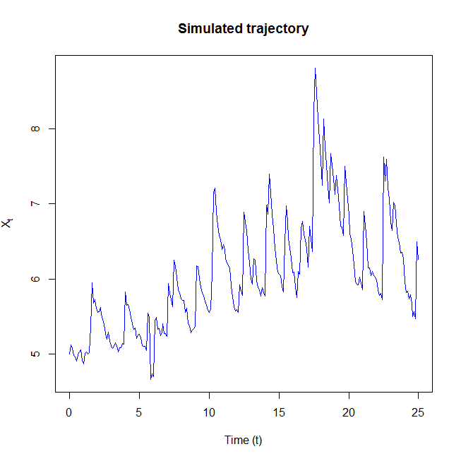

```r
library(DiffusionRjgqd)
data(JSDEsim1)
attach(JSDEsim1)
plot(JSDEsim1$Xt~JSDEsim1$time,type='l',col='blue',xlab='Time (t)',ylab=expression(X[t]),main='Simulated trajectory')
```

Here, `JSDEsim1` denotes a simulated dataset where a single trajectory of the model process is simulated and subsequently recorded at equispaced points along a finite observation horizon. For this dataset, $X_t$ is observed at times $t_1 =0, t_2 = 0.1,\ldots,t_{251}=25$. In order to estimate parameters for the simulated jump diffusion we can define the model using the JGQD-syntax and call the `JGQD.mcmc()` which maximizes the likelihood via the random walk Metropolis-Hastings algorithm (RWMH). This should be familiar from the [**DiffusionRgqd**](https://cran.r-project.org/package=DiffusionRgqd). For purposes of the analysis we place priors on the parameters $\theta_4$ and $\theta_6$ where:
$$\begin{aligned}
\theta_4 &\sim \mbox{Gamma}(0.001,0.001),\\
\theta_6^2 &\sim \mbox{InvGamma}(0.001,0.001).\\
\end{aligned}$$

In **R**:

```r
# Define the model:
JGQD.remove()
G0 <- function(t){theta[1]*theta[2]}
G1 <- function(t){-theta[1]}
Q1 <- function(t){theta[3]*theta[3]}
Jmu  <- function(t){theta[5]}
Jsig <- function(t){theta[6]}
Lam1 <- function(t){theta[4]}
priors <- function(theta)
{
 dgamma(theta[4],0.001,0.001)*dgamma(1/theta[6]^2,0.001,0.001)
}

# Define some starting parameters and run the MCMC:
updates <- 50000
burns   <- 10000
theta   <- c(10,10,2,2,0,1)
sds     <- c(0.154,0.171,0.037,0.156,0.155,0.2)/4
model_1 <- JGQD.mcmc(JSDEsim1$Xt,JSDEsim1$time,mesh=20,theta=theta,sds=sds,
                    updates=updates,burns=burns)
```

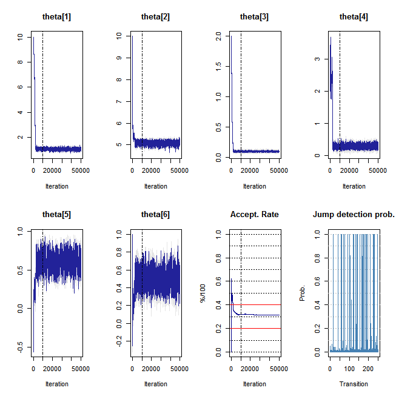

```
================================================================
            Jump Generalized Quadratic Diffusion (JGQD)
 ================================================================
 _____________________ Drift Coefficients _______________________
 G0 : theta[1]*theta[2]
 G1 : -theta[1]
 G2
 ___________________ Diffusion Coefficients _____________________
 Q0
 Q1 : theta[3]*theta[3]
 Q2
 _______________________ Jump Components ________________________
 Lam0
 Lam1 : theta[4]
 ........................... Jumps ..............................
 Normal
 Jmu : theta[5]
 Jsig : theta[6]
 __________________ Distribution Approximant ____________________
 Density approx. : Saddlepoint
 Trunc. Order    : 4
 Dens.  Order    : 4
=================================================================

 _______________________ Jump Components ________________________
 Chain Updates       : 50000
 Burned Updates      : 10000
 Time Homogeneous    : Yes
 Data Resolution     : Homogeneous: dt=0.1
 # Removed Transits. : None
 Density approx.     : 4 Ord. Truncation +4th Ord. Saddlepoint Appr.
 Elapsed time        : 00:04:12
 ...   ...   ...   ...   ...   ...   ...   ...   ...   ...   ...
 dim(theta)          : 6
 DIC                 : -267.962
 pd (eff. dim(theta)): 5.708
 ----------------------------------------------------------------
```

In order to calculate parameter estimates from the resulting MCMC output, we make use of the `JGQD.estimates()` function:

```r
JGQD.estimates(model_1,thin=200,burns)
```

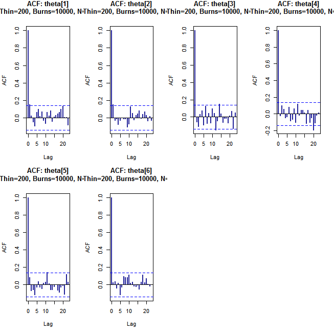

```
         Estimate Lower_CI Upper_CI
theta[1]    1.046    0.899    1.200
theta[2]    5.072    4.928    5.190
theta[3]    0.100    0.091    0.109
theta[4]    0.271    0.193    0.367
theta[5]    0.616    0.449    0.785
theta[6]    0.502    0.358    0.635
```

One of the features of the methodology which underpins the package is that it affords the opportunity to handle the unobserved jump sequence (to an extent). During execution of the MCMC algorithm, `JGQD.mcmc()` will attempt to decode and estimate the probability of each transition containing a jump. This can be acccessed via the `model_1$decode.prob` vactor. For comparison we have included the true sequnce of transitions which contain jumps. Subsequently we compare the estimated and true jump sequences:

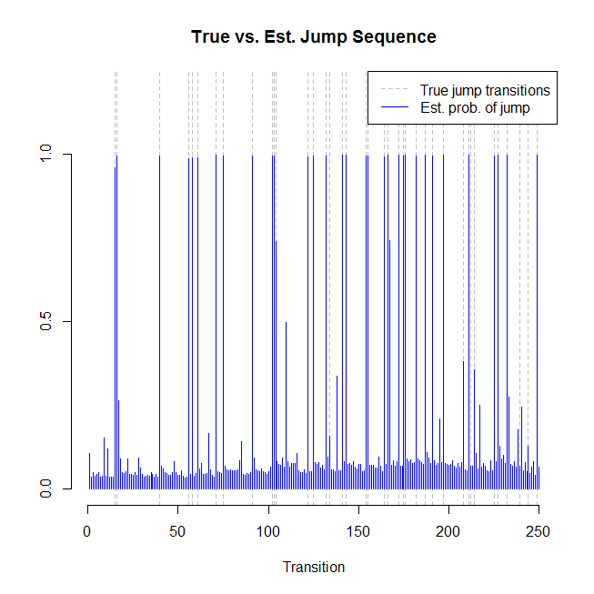

```r
plot(JSDEsim1$contains_jump[-1],type='n',ylim=c(0,1.2),axes=F,
     main='True vs. Est. Jump Sequence',xlab='Transition',ylab='')
abline(v=which(JSDEsim1$contains_jump[-1]==1),col='gray75',lty='dashed')
lines(model_1$decode.prob,type='h',col='blue')
axis(1)
axis(2,seq(0,1,1/2))
legend('topright',legend = c('True jump transitions','Est. prob. of jump'),col=c('gray75',4),bty='o',lty=c('dashed','solid'),bg='white')
```

For the simulated dataset, we can to a reasonable degree of accuracy decode which observed transitions most likely contain jumps. Naturally, the sequence of probabilities are based on the model being used, so results may vary, but asssuming that the jump signal is sufficiently strong we should be able to detect a good number of jumps in the data.

## A bivariate non-linear, coupled process with bivariate Normal jump distribution

Following along the lines of the previous example, we investigate a simulated a bivariate jump diffusion process. Using similar techniques to the scalar case we can accurately approximate the transitional density of a biavariate jump diffusion. Using the transition density approximation in conjunction with the likelihood expression we can perform inference just as in the scalar case. For purposes of the demonstration we consider a non-linear time homogeneous model of the form:

$$\begin{aligned}
dP_t^1&=\dot{z}_1dN_t^1\\
dP_t^2&=\dot{z}_2dN_t^1\\
\end{aligned}$$

with intensity $\lambda(X_t,Y_t) = 1$ and where
$$\{\dot{z}_1,\dot{z}_2\}^\prime\sim\mbox{Bivariate Normal}(\{0.5,0.5\}^\prime,\mbox{diag}(\{0.5^2,0.5^2\}^\prime)).$$
For convenience we have included a simulated dataset for this model which can be called using `data(JSDEsim2)`. Additionally, the corresponding sequence of jumps and jump arrival times were recorded in the dataset `JSDEsim3`. Although the true jump sequence plays no role in performing inference using the approximate likelihood function, it is useful to compare the parameter estimates that result from the indirect estimates of the jump mechanism parameters (indirectly observed via the jump diffusion) to estimates based on the true jump realisations. Subsequently, we can run the experiment using the **R** code:

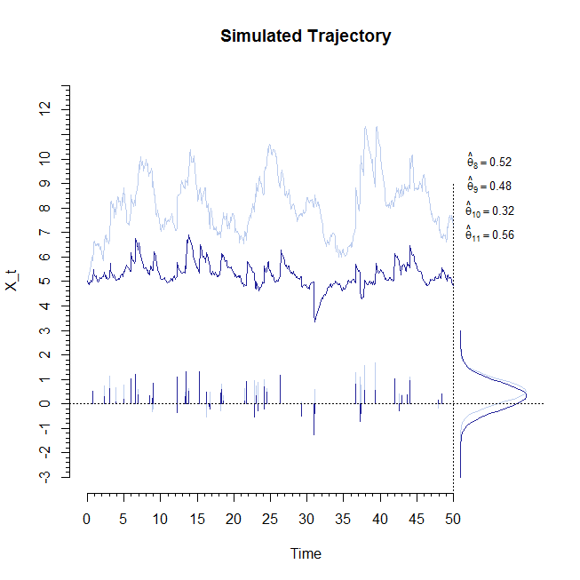

```r
library(DiffusionRjgqd)
data(JSDEsim2)
attach(JSDEsim2)
data(JSDEsim3)
attach(JSDEsim3)

plot(JSDEsim2$Xt~JSDEsim2$time,type='l',col='#BBCCEE',ylim=c(-3,13),xlim=c(0,60),axes=F,main='Simulated Trajectory',xlab = 'Time',ylab ='X_t')
lines(JSDEsim2$Yt~JSDEsim2$time,type='l',col='#222299')

axis(1,at=seq(0,50,5))
axis(1,at=seq(0,50,5/5),tcl=-0.2,labels=NA)
axis(2,at=seq(-3,13,1))
axis(2,at=seq(-3,13,1/5),tcl=-0.2,labels=NA)

lines(Xjumps~Jtime,type='h',col='#BBCCEE')
lines(Yjumps~Jtime,type='h',col='#222299')
mx=mean(Xjumps)
sx=sd(Xjumps)
my=mean(Yjumps)
sy=sd(Yjumps)
segments(50,-5,50,9,lty='dotted')
xx=seq(-3,3,1/10)
yy=dnorm(xx,mx,sx)
yy = (yy-min(yy))/(max(yy)-min(yy))*9+51*1
lines(xx~yy,col='#BBCCEE')
yy=dnorm(xx,my,sy)
yy = (yy-min(yy))/(max(yy)-min(yy))*9+51*1
lines(xx~yy,col='#222299')

text(55,10.0,substitute(hat(theta)[8]==a,list(a=round(mx,2))),cex=0.8)
text(55,9.0,substitute(hat(theta)[9]==a,list(a=round(sx,2))),cex=0.8)
text(55,8.0,substitute(hat(theta)[10]==a,list(a=round(my,2))),cex=0.8)
text(55,7.0,substitute(hat(theta)[11]==a,list(a=round(sy,2))),cex=0.8)
abline(h=0,lty='dotted')
```

The figure above shows a simulated trajectory for the jump diffusion ($X_t$ in lightblue and $Y_t$ in dark blue) and the corresponding sequence of jumps. From the jump sequence we calculate parameter estimates for the jump distribution parameters and superimpose the resulting density functions in the right peripheral of the plot. Note that, despite the true parameters for the marginals of the jump distribution being equal, the estimates calculated from the directly observed jump sequence differ slightly. Specificlally, the parameter estimate for `theta[9]` is somewhat lower than the true value. This seems to suggest that the sequence of jumps may contain values which are improbable (but not impossible) under the true model. Now, for purposes of the experiment we can perform inference via the jump diffusion (in which case, again, the true jump sequence is not used in the likelihood evaluation directly but only through its effect on the trajectory of the jump diffusion) and compare the resulting estimates to that of the true parameter set:

```r
X=cbind(JSDEsim2$Xt,JSDEsim2$Yt)

# Define the model:
JGQD.remove()
a00 <-function(t){theta[1]*theta[2]}
a10 <-function(t){-theta[1]}
a01 <-function(t){theta[1]}
c11 <-function(t){theta[3]*theta[3]}

b00 <-function(t){theta[4]*theta[5]}
b01 <-function(t){-theta[4]}
f01 <-function(t){theta[6]*theta[6]}

# Constant intensity
Lam00= function(t){theta[7]}

# Normal jumps:
Jmu1   <-function(t){theta[8]}
Jmu2   <-function(t){theta[9]}
Jsig11 <-function(t){theta[10]*theta[10]}
Jsig22 <-function(t){theta[11]*theta[11]}

# Some starting parameters:
theta  <-c(rep(1,11))
sds    <-c(0.08,0.22,0.01,0.04,0.16,0.01,0.10,0.07,0.09,0.05,0.09)/2
burns  <-10000
updates<-50000

res <-BiJGQD.mcmc(X,JSDEsim2$time,mesh=10,theta,sds,updates,burns=burns)
```

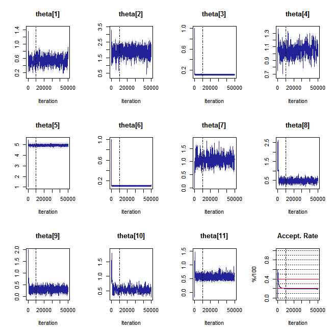

```
Compiling C++ code. Please wait.


 ================================================================
                   GENERALIZED QUADRATIC DIFFUSON
 ================================================================
 _____________________ Drift Coefficients _______________________
 a00 : theta[1]*theta[2]
 a10 : -theta[1]
 a01 : theta[1]
 ...   ...   ...   ...   ...   ...   ...   ...   ...   ...   ...
 b00 : theta[4]*theta[5]
 b01 : -theta[4]
 ___________________ Diffusion Coefficients _____________________
 c11 : theta[3]*theta[3]
 ...   ...   ...   ...   ...   ...   ...   ...   ...   ...   ...
 ...   ...   ...   ...   ...   ...   ...   ...   ...   ...   ...
 ...   ...   ...   ...   ...   ...   ...   ...   ...   ...   ...
 f01 : theta[6]*theta[6]
 _______________________ Jump Components ________________________
 ......................... Intensity ............................
 Lam00 : theta[7]
 ........................... Jumps ..............................
 Jmu1 : theta[8]
 Jmu2 : theta[9]
 Jsig11 : theta[10]*theta[10]
 Jsig22 : theta[11]*theta[11]
 _____________________ Prior Distributions ______________________

 d(theta):None.
 ================================================================

 _______________________ Model/Chain Info _______________________
 Chain Updates       : 50000
 Burned Updates      : 10000
 Time Homogeneous    : Yes
 Data Resolution     : Homogeneous: dt=0.1
 # Removed Transits. : None
 Density approx.     : 4th Ord. Truncation, Bivariate-Saddlepoint
 Elapsed time        : 00:14:28
 ...   ...   ...   ...   ...   ...   ...   ...   ...   ...   ...
 dim(theta)          : 11
 DIC                 : -855.021
 pd (eff. dim(theta)): 10.704
 ----------------------------------------------------------------
```

```r
JGQD.estimates(res,thin=200,burns=burns)
```

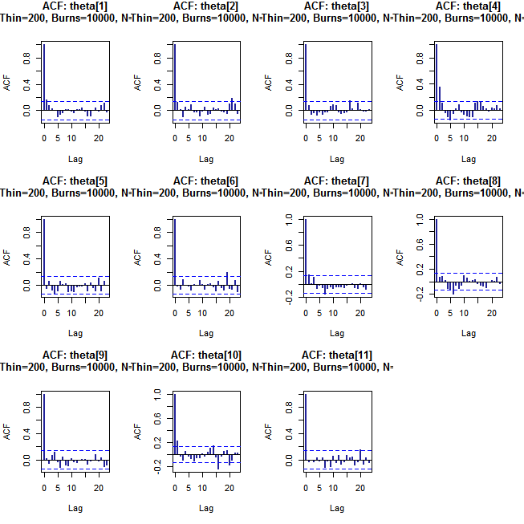

```
         Estimate Lower_CI Upper_CI
theta[1]     0.535    0.357    0.694
theta[2]     1.889    1.458    2.253
theta[3]     0.109    0.102    0.114
theta[4]     1.046    0.923    1.192
theta[5]     4.958    4.878    5.035
theta[6]     0.106    0.099    0.112
theta[7]     1.061    0.809    1.364
theta[8]     0.479    0.315    0.625
theta[9]     0.314    0.171    0.459
theta[10]    0.528    0.405    0.673
theta[11]    0.560    0.463    0.674
```

Note that the parameter estimates are quite accurate and that the lower estimate for `theta[9]` is preserved in the jump diffusion parameter estimates. This serves to highlight that even under ideal conditions (the dataset was reasonably long and observed at reasonably high resolution) it is possible for the observed series to contain unllikely observations under the true data generating process. Consequently, it is important when interpreting parameter estimates to understand how the data resolution effects the analysis and how some elements of the model may be difficult to pin down.

# A jump diffusion model of **Google** equity volatility

Perhaps the most cited use of jump diffusion models are in the field of mathematical finance. An important application of jump diffusion processes in finance is the modeling of volatility processes. One of the most famous of these is the S&P 500 volatility index (VIX), which serves as a measure of volatility for an index of the S&P 500 index of securities. Although the S&P 500 has been the subject of numerous empirical studies, highly traded individual securities have enjoyed similar interest in recent times. Indeed, the [Chicago Board Options Exchange (CBOE)](https://www.cboe.com/) now provides equity volatility indices for a couple of hoghly traded stocks that are based on similar methods as the VIX. For purposes of this example we consider the equity volatility of internet search giant, **Google**. Using the [**Quandl** package](https://cran.r-project.org/package=Quandl) (McTaggart and Daroczi 2015), we can source data in **R** for **Google** equity volatility (VXGOG) directly:

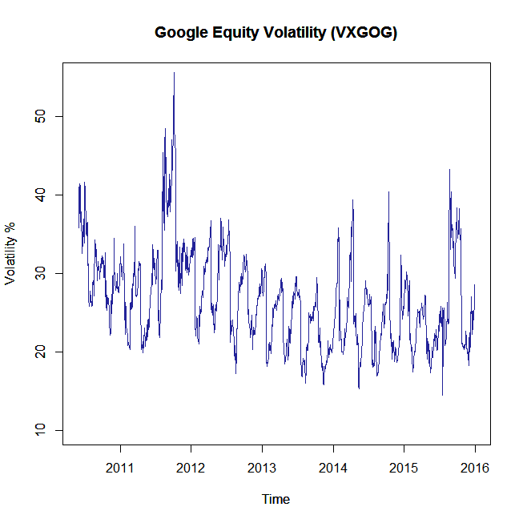

```r
 library(DiffusionRjgqd)
 library(Quandl)

 # Source data for the Google equity volatility:
 quandldata1 <- Quandl("CBOE/VXGOG", collapse="daily",
 start_date="2010-03-11",end_date="2016-01-01", type="raw")
 Vt <- rev(quandldata1[,names(quandldata1)=='Close'])
 time1 <-rev(quandldata1[,names(quandldata1)=='Date'])

 # Make a plot of the data
 plot(Vt~time1,type='l',col='#222299',ylim=c(10,55),main='Google Equity Volatility (VXGOG)',
      xlab = 'Time',ylab ='Volatility %',lwd=1)
```

$$\begin{aligned}
dX_t &= \theta_1\big(\theta_2+\theta_7\sin\big(8\pi t + (\theta_8-0.5) 2 \pi\big)\big)-X_t)dt+\theta_3X_tdB_t +dP_t\\
dP_t &= \dot{z}_tdN_t\\
\end{aligned}$$
where $\lambda(X_t,t) = \theta_4X_t$ and $\dot{z}_t\sim \mbox{N}(\theta_5,\theta_6^2)$. Note that this is a relatively complicated model. Typically such an analysis would consist of fitting a plethora of models and finding a most likeliy candidate based on model fit statistics. However, this can be a lengthy process and *we cut to the chase* for this example (a more in-depth study of this dataset can be found in the methodology paper). The model presented here contains a cyclical drift component corresponding to a quarterly volatility cycle, state-dependent volatility (i.e., the volatility of volatility varies in accordance with the level of the process) and state-dependent jump intensity. That is, we postulate that the arrival rate for jump events varies in accordance with the level of volatility. Consequently jumps are more likely when volatility is high as opposed to when it is low.

In order to facilitate the estimation procedure we place some prior distributions on the parameter space:
$$\begin{aligned}
\theta_1 &\sim \mbox{Gamma}(0.001,0.001)\\
\theta_2 &\sim \mbox{N}(25,5^2)\\
\theta_3^2 &\sim \mbox{InvGamma}(0.001,0.001)\\
\theta_4 &\sim \mbox{Gamma}(0.001,0.001)\\
\theta_6^2 &\sim \mbox{InvGamma}(0.001,0.001)\\
\theta_7 &\sim \mbox{Gamma}(0.001,0.001)\\
\theta_8 &\sim \mbox{Beta}(0.5,0.5).\\
\end{aligned}$$
Note that the priors are mostly uninformative, however, they do serve to restrict relevant parameters to appropriate domains. For example, $\theta_8$ is restricted to the interval $[0,1]$ since the likelihood would contain multiple identical modes otherwise. Using the `JGQD.mcmc()` we can fit the jump diffusion process to the observed series and calculate parameter estimates:

```r
 JGQD.remove()
 G0  <- function(t){theta[1]*theta[2] + theta[1]*theta[7]*sin(8*pi*t + (theta[8] - 0.5)*2*pi)}
 G1  <- function(t){-theta[1]}
 Q2  <- function(t){theta[3]*theta[3]}
 Lam1<- function(t){theta[4]}
 Jmu <- function(t){theta[5]}
 Jsig<- function(t){theta[6]}

  priors<-function(theta)
 {
   rs =dgamma(theta[1], 0.001, 0.001)*
   dnorm(theta[2], 25, 5)*
   dgamma(1/theta[3]^2, 0.001, 0.001)*
   dgamma(theta[4], 0.001, 0.001)*
   dgamma(1/theta[6]^2, 0.001, 0.001)*
   dgamma(theta[7], 0.001, 0.001)*
   dbeta(theta[8],0.5,0.5)
   if(is.na(rs)){return(0.000000000001)}
   return(rs)
 }


 X       <- Vt
 time    <- cumsum(c(0, diff(as.Date(time1))*(1/365)))
 updates <- 100000
 burns   <- 25000
 theta   <- c(50, 50, sqrt(5), 5, 5, 5, 50, 0.1)
 sds     <- c(1.87, 2.96, 0.02, 0.17, 0.39, 0.40, 0.71, 0.03)/1.5
 model_1 <- JGQD.mcmc(X, time, 5, theta, sds, updates, burns)
```

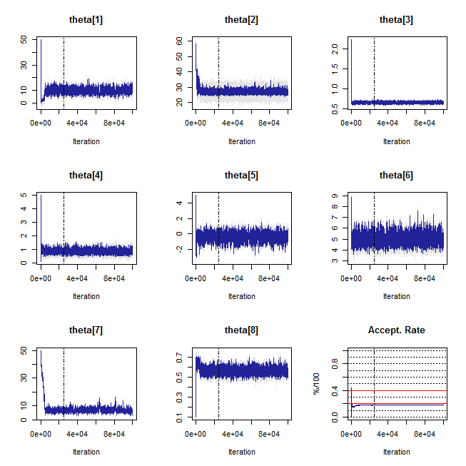

```
 ================================================================
            Jump Generalized Quadratic Diffusion (JGQD)
 ================================================================
 _____________________ Drift Coefficients _______________________
 G0 : theta[1]*theta[2]+theta[1]*theta[7]*sin(8*pi*t+(theta[8]-0.5)*2*pi)
 G1 : -theta[1]
 G2
 ___________________ Diffusion Coefficients _____________________
 Q0
 Q1
 Q2 : theta[3]*theta[3]
 _______________________ Jump Components ________________________
 Lam0
 Lam1 : theta[4]
 ........................... Jumps ..............................
 Normal
 Jmu : theta[5]
 Jsig : theta[6]
 __________________ Distribution Approximant ____________________
 Density approx. : Saddlepoint
 Trunc. Order    : 4
 Dens.  Order    : 4
=================================================================

 _______________________ Jump Components ________________________
 Chain Updates       : 1e+05
 Burned Updates      : 25000
 Time Homogeneous    : No
 Data Resolution     : Variable: min(dt)=0.0027, max(dt)=0.0137
 # Removed Transits. : None
 Density approx.     : 4 Ord. Truncation +4th Ord. Saddlepoint Appr.
 Elapsed time        : 00:23:49
 ...   ...   ...   ...   ...   ...   ...   ...   ...   ...   ...
 dim(theta)          : 8
 DIC                 : 4751.671
 pd (eff. dim(theta)): 7.99
 ----------------------------------------------------------------
```

```r
 # Calculate parameter estimates:
 ests <- JGQD.estimates(model_1, thin = 200, burns)
 ests
```

```
          Estimate Lower_CI Upper_CI
theta[1]    9.811    6.547   13.069
theta[2]   27.166   25.747   28.828
theta[3]    0.661    0.629    0.691
theta[4]    0.844    0.627    1.105
theta[5]   -0.370   -1.225    0.502
theta[6]    5.038    4.313    5.905
theta[7]    7.077    5.050    9.846
theta[8]    0.566    0.518    0.617
```

From a modeling perspective, the use of a jump diffusion can be made clear by comparing the model fit to traditional diffusion models. For example, compared to its jump-free counterpart – a time-inhomogeneous CIR model of the equity volatility (here, the [**DiffusionRgqd**](https://cran.r-project.org/package=DiffusionRgqd) . package can be used to fit the jump-free model):

```r
 # Purely diffuse process:
 library(DiffusionRgqd)
 GQD.remove()
 G0 <- function(t){theta[1]*theta[2] + theta[1]*theta[4]*sin(8*pi*t + (theta[5] - 0.5)*2*pi)}
 G1 <- function(t){-theta[1]}
 Q2 <- function(t){theta[3]*theta[3]}
 priors <- function(theta)
 {
   rs =dgamma(theta[1], 0.001, 0.001)*
   dnorm(theta[2], 25, 5)*
   dgamma(1/theta[3]^2, 0.001, 0.001)*
   dgamma(theta[4], 0.001, 0.001)*
   dbeta(theta[5], 0.5, 0.5)
   if(is.na(rs)){return(0.000000000001)}
   return(rs)
 }

 theta   <- c(50, 50, sqrt(5), 10, 0.1)
 sds     <- c(2.87, 2.96, 0.02, 1.21, 0.03)/2
 model_2 <- GQD.mcmc(X, time, 5, theta, sds, updates, burns, print.output = FALSE)
```

a comparison of DIC reveals a substantial improvement in fit:

```r
 #  Compare DIC values:
 JGQD.dic(list(model_1, model_2))
```

```
        Elapsed_Time Time_Homogeneous       p          DIC      pD    N
Model 1     00:23:49               No    8.00  [=] 4751.67    7.99 1409
Model 2     00:08:24               No    5.00      5449.00    5.17 1409
```

Although the parameter estimates can give an indication as to the dynamics of the jump mechanism of the process, the `JGQD.mcmc()` function provides a usefull statistic for assessing the probability of jump events. From the model output we can access the list variable `$zero.jump` which gives the estimated mean probability of observing at least one jump at each iteration of the MCMC run. We may thus draw a frequency histogram of said probability in order to gain insiight into the *fitted* likelihood of a jump arrival for a typical transition.

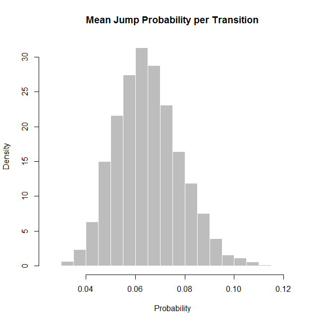

```r
 # Make a histogram of the mean jump probability per transition horizon:
 hist(model_1$zero.jump[seq(burns,updates,1)], freq= FALSE, col='gray74',
       border = 'white', xlab = 'Probability', main = 'Mean Jump Probability per Transition')
```

Based on the histogram we can expect to see at least one jump in volatility on any given trading day with a probability of around 6.5%.

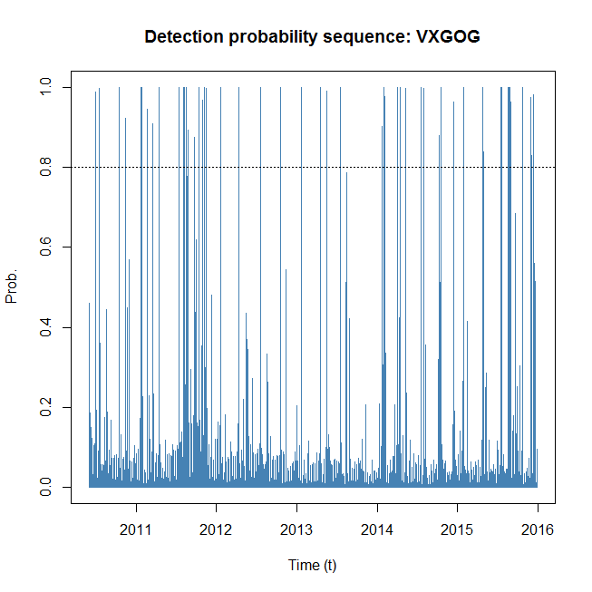

```r
plot(model_1$decode.prob~time1[-1], type='h', ylim = c(0, 1), xlab ='Time (t)',
     ylab= 'Prob.',main ='Detection probability sequence: VXGOG',col = 'steelblue')
abline(h=0.8,lty='dotted')
```

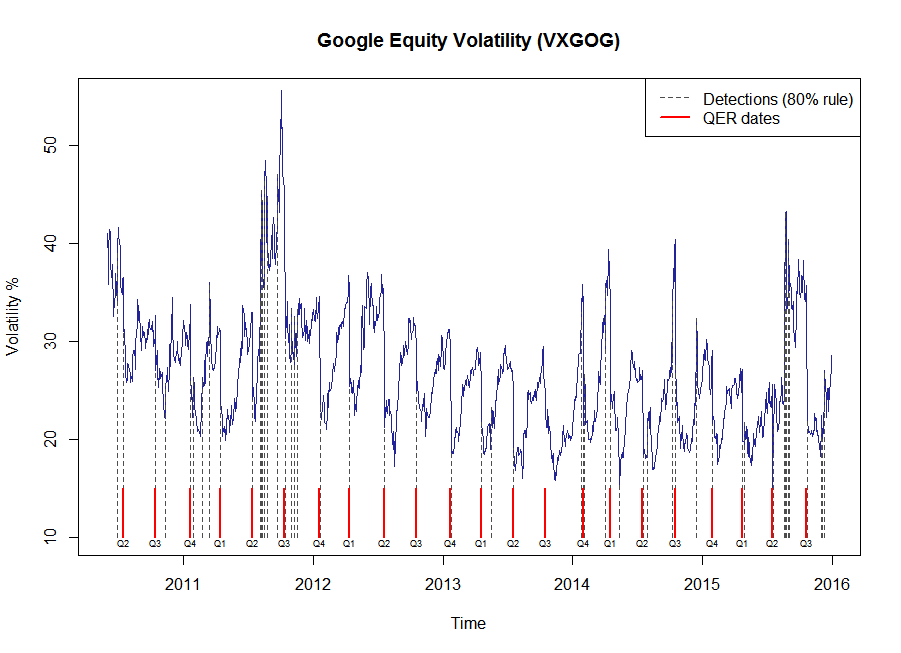

```r
# Earnings report dates (appr):
QERs<-c("2010-07-16",
        "2010-10-14",
        "2011-01-20",
        "2011-04-14",
        "2011-07-14",
        "2011-10-13",
        "2012-01-19",
        "2012-04-12",
        "2012-07-19",
        "2012-10-18",
        "2013-01-22",
        "2013-04-18",
        "2013-07-18",
        "2013-10-17",
        "2014-01-30",
        "2014-04-16",
        "2014-07-17",
        "2014-10-16",
        "2015-01-29",
        "2015-04-23",
        "2015-07-16",
        "2015-10-22")
QS <- c(2, 3, 4, 1, 2, 3, 4, 1, 2, 3, 4, 1, 2, 3, 4, 1, 2, 3, 4, 1, 2, 3)
plot(Vt~time1, type = 'l', col = '#222299', ylim=c(10, 55), main='Google Equity Volatility (VXGOG)',
     xlab = 'Time', ylab = 'Volatility %')
at.dates <- c(time1[-1])[which(model_1$decode.prob > 0.8)]

for(i in 1:length(at.dates))
{
  segments(at.dates[i], 10, at.dates[i], Vt[which(time1==at.dates[i])], col='grey30',lty='dashed')
}
QERdates <- as.Date(QERs)
for(i in 1:length(at.dates))
{
  segments(QERdates[i], 10, QERdates[i], 15, col = 'red', lty = 'solid', lwd = 2)
}
text(QERdates, 9.5, labels = paste0('Q', QS), cex = 0.6)
legend('topright', legend = c('Detections (80% rule)', 'QER dates'), lty=c('dashed', 'solid'),
       col = c('grey30', 'red'), lwd=c(1, 2), bg = 'white')
```

# Further reading

- Methodology paper and replication materials.
- Related packages:
  - [**DiffusionRgqd**](https://cran.r-project.org/package=DiffusionRgqd)
- More Vignettes:
  - Introduction
  - Transitional densities
  - Bivariate diffusions
  - Likelihood inference
  - Or use:

```r
browseVignettes('DiffusionRjgqd')
```

# References

Honore, Peter. 1998. “Pitfalls in Estimating Jump-Diffusion Models.” *Available at SSRN 61998*.

McTaggart, Raymond, and Gergely Daroczi. 2015. *Quandl: API Wrapper for Quandl.com*. http://CRAN.R-project.org/package=Quandl.